# Lab 14: Aesthetic Mappings

## Miles Per Gallon

Make sure to start by running the setup chunk above to load the required packages. Then, read in the mpg dataset. There is one row for each particular type of car, with information about the fuel efficiency and other metadata.

```r
mpg <- read_csv("https://statsmaths.github.io/stat_data/mpg.csv")
```

The variable `displ` gives the size of the engine in litres and `cty` the reported miles per gallon of the car while driving in stop-and-go city traffic. Likewise, `hwy` is the miles per gallon for a car on the highway.

Start by making a scatter plot (i.e., points) of engine size on the x-axis and the highway fuel efficiency on the y-axis.

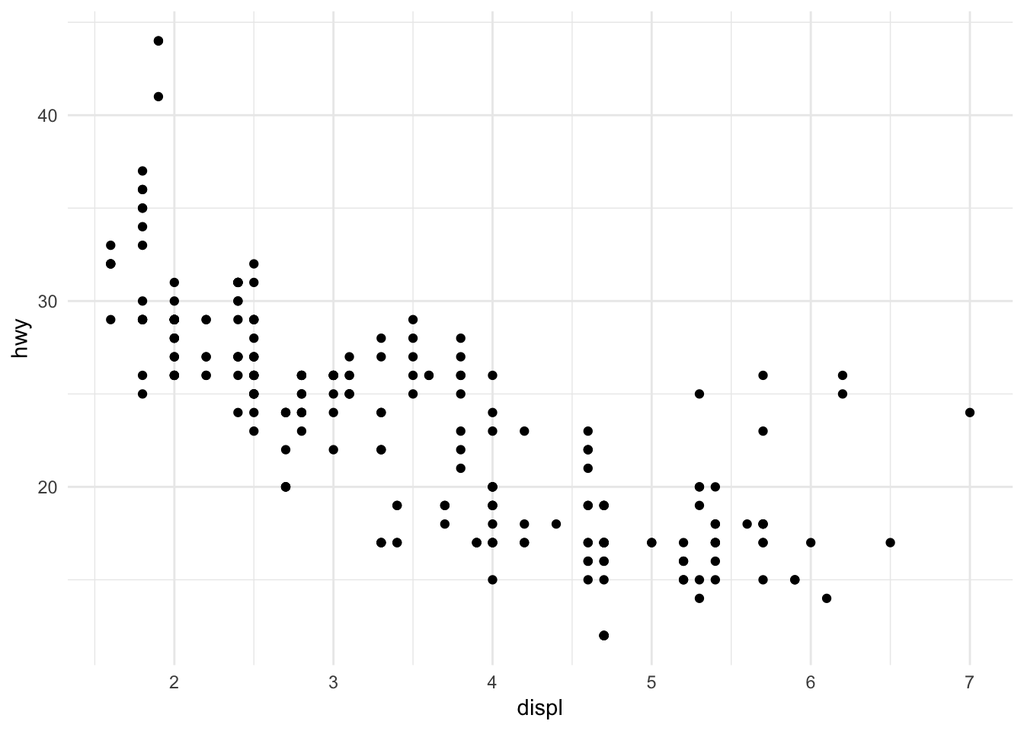

```r
ggplot(mpg, aes(displ, hwy)) +
  geom_point()
```

Verify that the pattern in this plot makes sense.

Next, modify the plot so that the color of the points show the class of the vehicle.

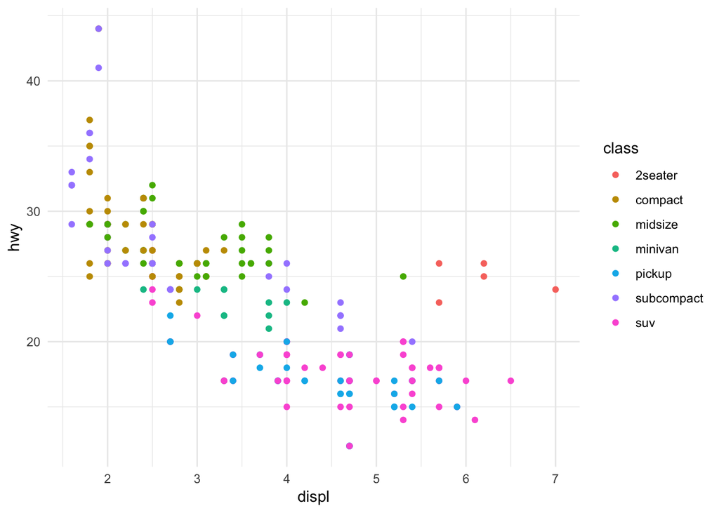

```r
ggplot(mpg, aes(displ, hwy)) +
  geom_point(aes(color = class))
```

Identify a few different classes of vehicles and verify that they appear where you would expect on the plot.

Now, make all of the points in the plot twice as big and color them the color green.

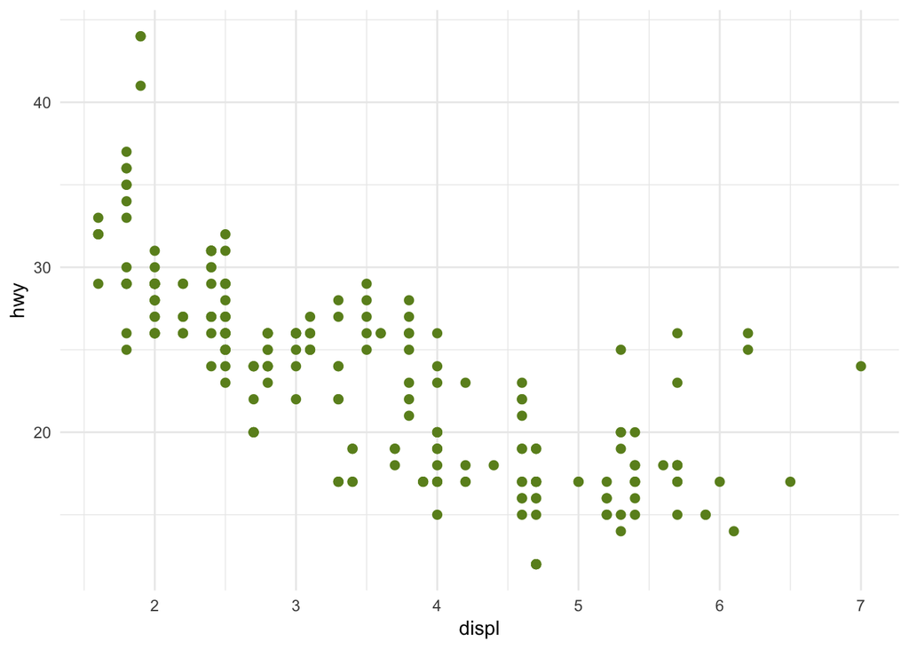

```r
ggplot(mpg, aes(displ, hwy)) +
  geom_point(size = 2, color="olivedrab")
```

Next, create two scatter plots at once by adding together `geom_point` layers where one layer uses `hwy` as the y-axis and the other users `cty` as the y-axis (yes, you can override the y aesthetic just like any other).

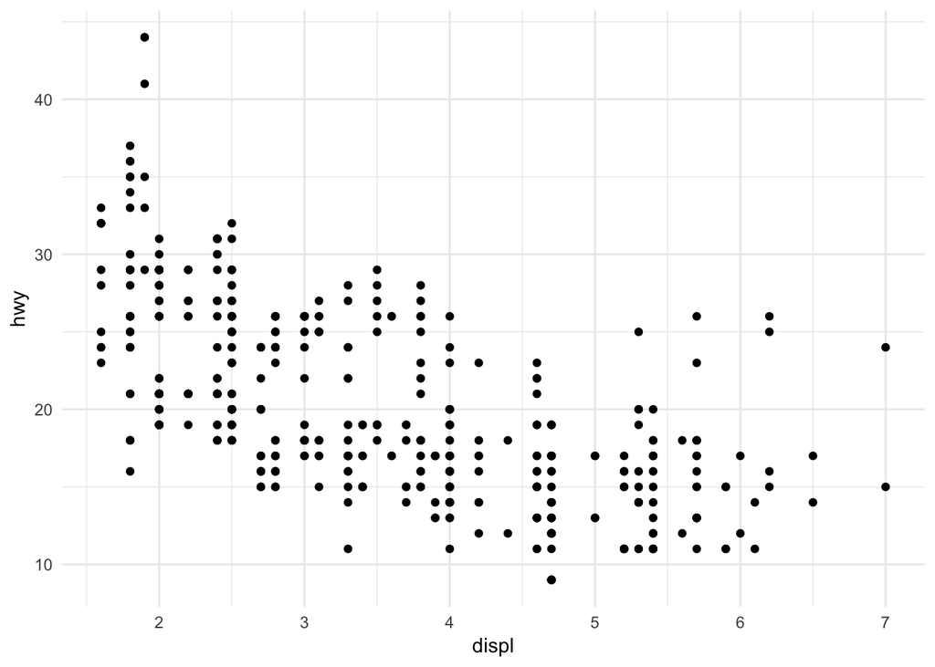

```r
ggplot(mpg, aes(displ, hwy)) +
  geom_point() +
  geom_point(aes(y = cty))
```

In the previous plot, it is impossible to distinguish between the points that are of the highway fuel efficiencies values and the city fuel efficiencies. Change this by making the city fuel efficiencies colored in red.

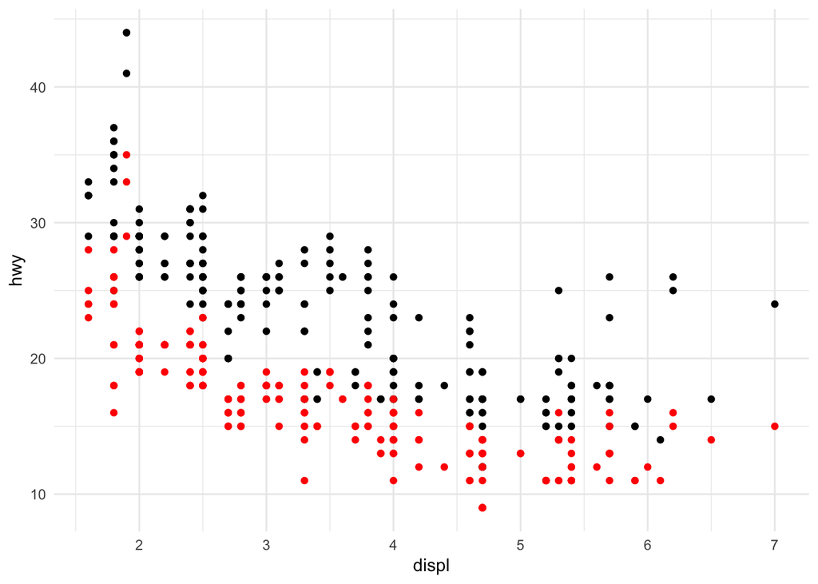

```r
ggplot(mpg, aes(displ, hwy)) +
  geom_point() +
  geom_point(aes(y = cty), color = "red")
```

The default y-axis label is no longer correct because it actually measures two different fuel efficiencies. Add the layer `ylab("Miles Per Gallon")` to the plot to fix this:

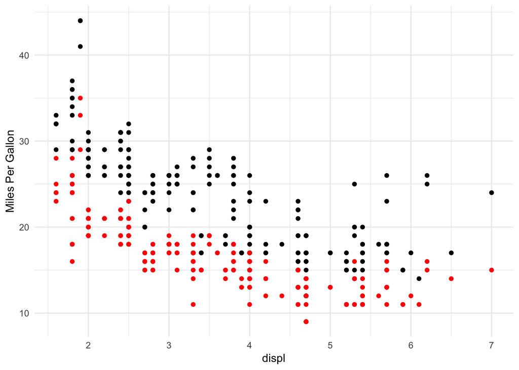

```r
ggplot(mpg, aes(displ, hwy)) +
  geom_point() +
  geom_point(aes(y = cty), color = "red") +
  ylab("Miles Per Gallon")
```

Finally, do the same with the `xlab` and `ggtitle` functions to add a better x-axis and title.

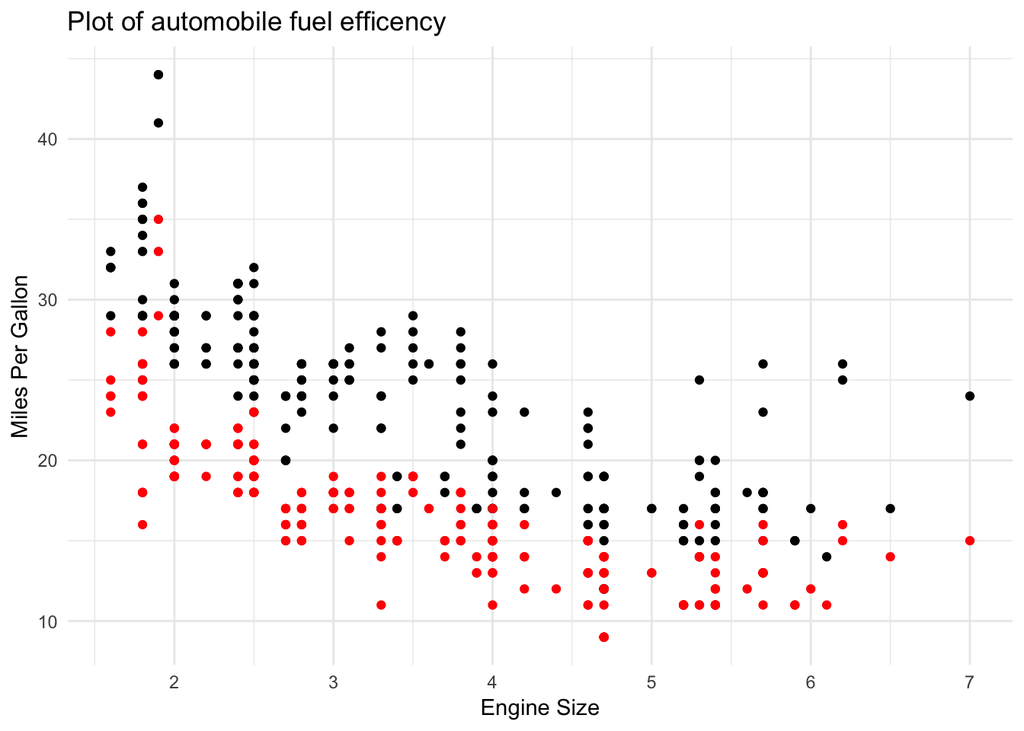

```r
ggplot(mpg, aes(displ, hwy)) +
  geom_point() +
  geom_point(aes(y = cty), color = "red") +
  ylab("Miles Per Gallon") +
  xlab("Engine Size") +
  ggtitle("Plot of automobile fuel efficency")
```

## Democratic Primary 2016

Now, load data from the 2016 Democratic Primary elections. The data is given at the county level (this is the **unit of analysis**).

```r
primary <- read_csv("https://statsmaths.github.io/stat_data/primary2016.csv")
```

Start by drawing a scatter plot of latitude and longitude (it is up to you to determine which goes on the x and y axes):

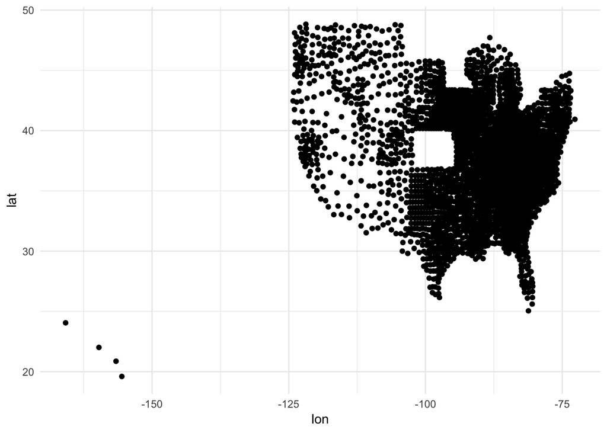

```r
ggplot(primary, aes(lon, lat)) +
  geom_point()
```

Next, color the points based on the variable `division`.

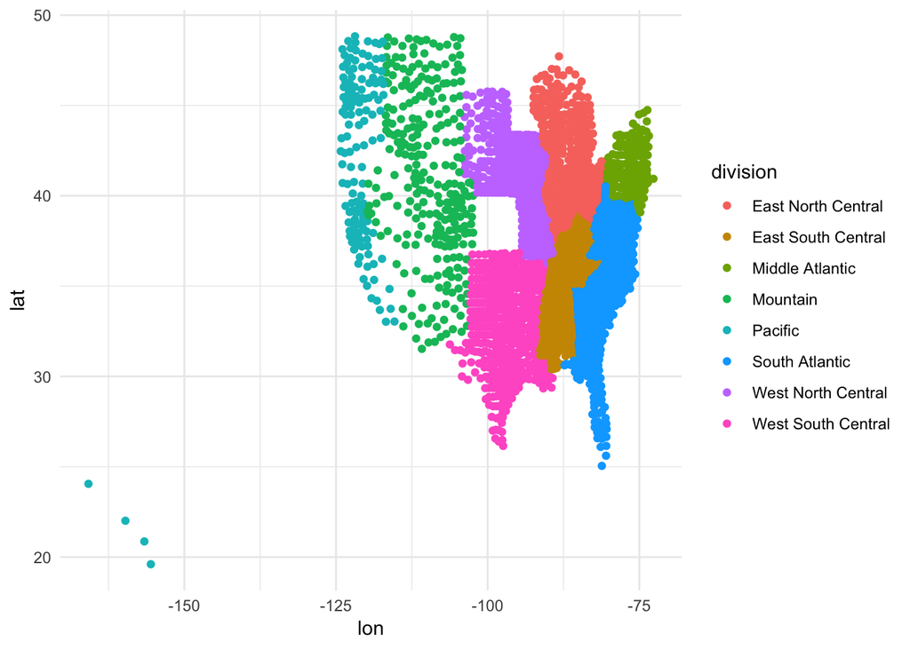

```r
ggplot(primary, aes(lon, lat)) +
  geom_point(aes(color = division))
```

Then, color the points based on the variable `prop_hillary` (the proportion of votes Hillary Clinton received).

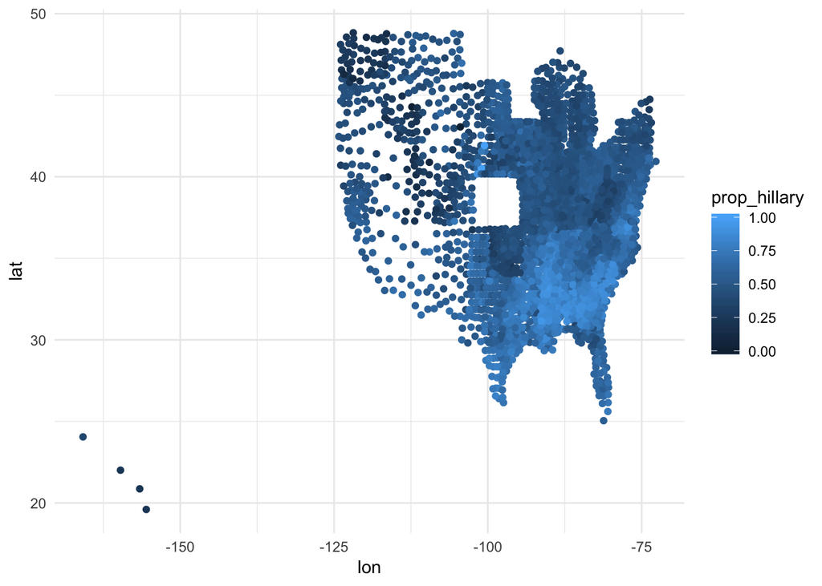

```r
ggplot(primary, aes(lon, lat)) +
  geom_point(aes(color = prop_hillary))
```

Notice any interesting patterns here? Try loading the **viridis** package:

```r
library(viridis)
```

And add `scale_color_viridis()` to the plot:

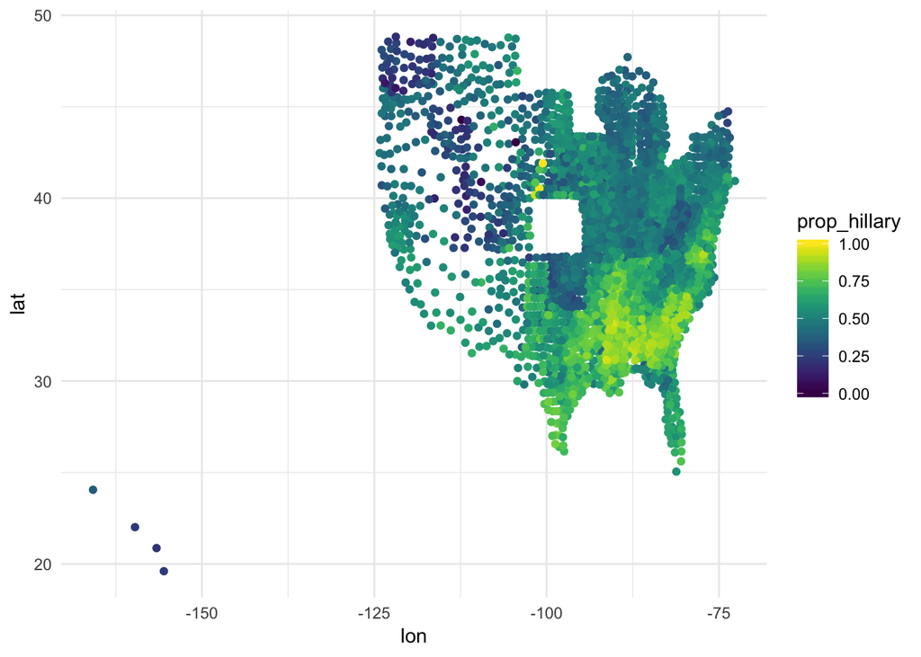

```r
ggplot(primary, aes(lon, lat)) +
  geom_point(aes(color = prop_hillary)) +
  scale_color_viridis()
```

BONUS:

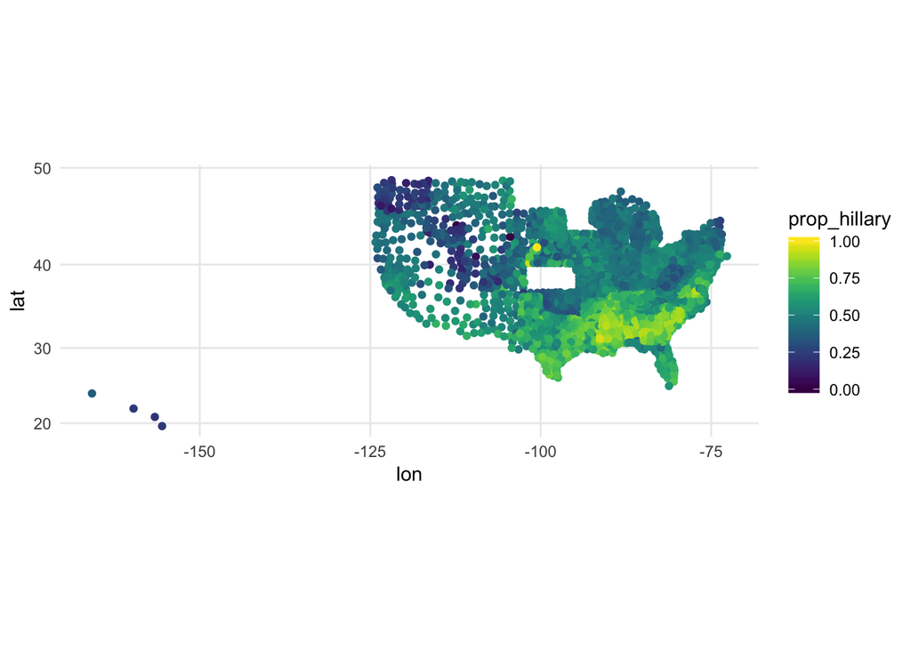

```r
ggplot(primary, aes(lon, lat)) +
  geom_point(aes(color = prop_hillary)) +
  scale_color_viridis() +
  coord_map()
```

It should look much more readable. Do you notice any patterns now?

## Burritos

Finally, we will look at a dataset of reviews of burritos in southern California. This is a data set collected by a group of college friends who live in the greater San Diego area.

```r
burrito <- read_csv("https://statsmaths.github.io/stat_data/burrito.csv")
```

The available variables in the data are:

- location: the name of the restaurant
- cost: total cost for the burrito
- yelp: the average Yelp review score
- google: the average Google review score
- chips_included: equals 1 if chips are included with the burrito
- hunger: score from 1 to 5 on how much the burrito filled up the reviewer
- tortilla: rating from reviewer; 1 (terrible) to 5 (awesome)
- temp: rating from reviewer; 1 (terrible) to 5 (awesome)
- meat: rating from reviewer; 1 (terrible) to 5 (awesome)
- fillings: rating from reviewer; 1 (terrible) to 5 (awesome)
- meat_filling: rating from reviewer; 1 (terrible) to 5 (awesome)
- uniformity: rating from reviewer; 1 (terrible) to 5 (awesome)
- salsa: rating from reviewer; 1 (terrible) to 5 (awesome)
- synergy: rating from reviewer; 1 (terrible) to 5 (awesome)
- wrap: rating from reviewer; 1 (terrible) to 5 (awesome)
- overall: rating from reviewer; 1 (terrible) to 5 (awesome)
- lat: latitude (in degrees North) of the taco restaurant
- lon: longitude (in degrees East) of the taco restaurant

Create a plot of longitude and latitude using a `geom_point` layer (you’ll want longitude on the x-axis):

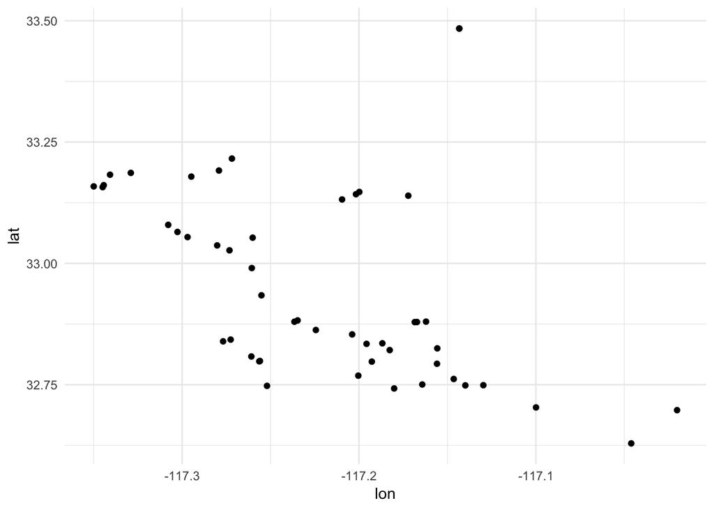

```r
ggplot(burrito, aes(lon, lat)) +
  geom_point()
```

Make a histogram for the variable synergy:

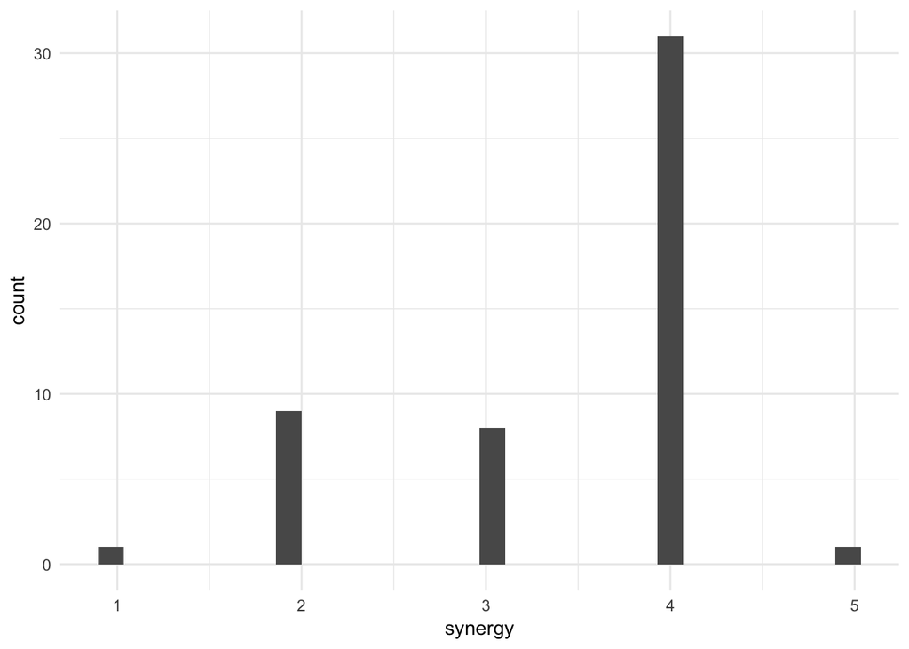

```r
ggplot(burrito, aes(synergy)) +
  geom_histogram()
```

Now, make a bar plot for the variable synergy. :

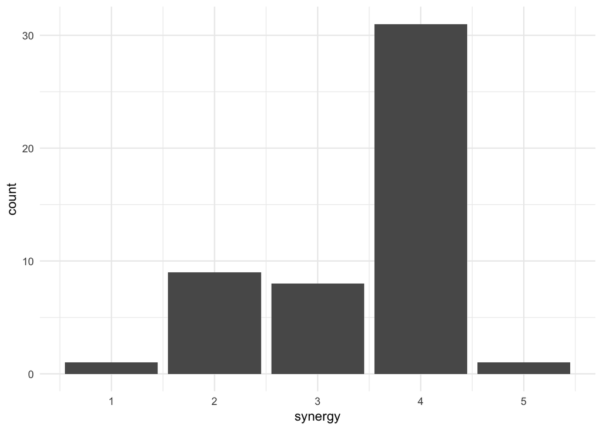

```r
ggplot(burrito, aes(synergy)) +
  geom_bar()
```

Do you like this more than the histogram? Why or why not?

Draw a scatterplot with google score on the x-axis and the yelp on the y-axis. Add a regression line to the plot:

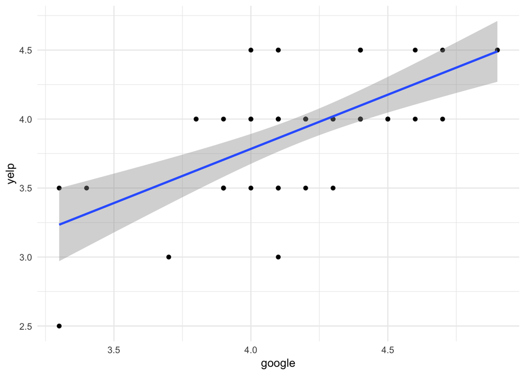

```r
ggplot(burrito, aes(google, yelp)) +
  geom_point() +
  geom_bestfit()
```

Finally, run a regression model in R to determine whether there is a significant relationship between the the Google and Yelp scores.

```r
tmod_linear_regression(yelp ~ google, data = burrito)
```

```
##
## Linear regression; T-Test
##
##  H0: Change in conditional mean is zero
##  HA: Change in conditional mean is non-zero
##
##  Test statistic: t = 5.6704
##  P-value: 7.959e-07
##
##  Parameter: change in yelp for unit change in google
##              controlling for --
##  Point estimate: 0.78513
##  Confidence interval: [0.50673, 1.06350]
```